# Percepción del equipo tratante sobre el modelo de psiquiatría de enlace

08-07-2026

## Resumen

Se encuestó a 27 profesionales del equipo tratante (Becado/a, Interno/a, Staff) sobre su percepción del modelo de psiquiatría de enlace. La escala de 12 ítems Likert tiene una consistencia interna muy alta (alpha de Cronbach = 0.92), y en general la evaluación es favorable: los ítems mejor evaluados son la facilidad de contacto y la oportunidad de respuesta del equipo, mientras que los peor evaluados son la reducción de la carga de trabajo/estrés y la continuidad de cuidados ambulatorios tras el alta — hallazgo que es consistente con los temas que el propio equipo tratante menciona espontáneamente como “aspectos a mejorar”.

## Metodología

- **Muestra**: 27 respuestas de conveniencia (no aleatoria), de un solo hospital. Se desglosa por cargo (Becado/a n = 15, Interno/a n = 5, Staff n = 7) pero **no** por sala, porque varias salas tienen solo 2-3 respuestas y el porcentaje por celda no sería confiable.
- **Escala Likert**: 12 ítems de acuerdo/desacuerdo a 5 niveles. Se grafican como barras divergentes (técnica estándar para Likert), repartiendo la categoría neutra en dos mitades a cada lado del cero.
- **Índice de satisfacción**: promedio de los 12 ítems Likert (1-5) por encuestado, correlacionado con años de experiencia y con interacciones mensuales con psiquiatría (Spearman, más robusto que Pearson para escalas ordinales con n pequeño).
- **Codificación temática**: las respuestas abiertas se codificaron a mano (una respuesta puede tocar más de un tema); el detalle está en `codificacion_tematica.R` para que sea auditable.
- **Limitaciones**: ver sección final.

## Características de la población

| **Característica** | **N = 27**<sup>1</sup> |
| --- | --- |
| Cargo |  |
| Becado/a | 15 (56%) |
| Interno/a | 5 (19%) |
| Staff | 7 (26%) |
| Sala |  |
| Agudo | 2 (7.4%) |
| Cirugía | 3 (11%) |
| Medico quirurgico cardiológico | 4 (15%) |
| Sala J | 8 (30%) |
| Sala L | 7 (26%) |
| Traumatología | 3 (11%) |
| Años de experiencia | 5.0 (3.0, 7.0) |
| Sin dato | 1 |
| Años trabajando en el hospital | 1.0 (0.3, 3.0) |
| Interacciones con psiquiatría (último mes) | 3.0 (2.0, 10.0) |

<sup>1</sup> n (%); Median (Q1, Q3)

## Percepción general del equipo tratante

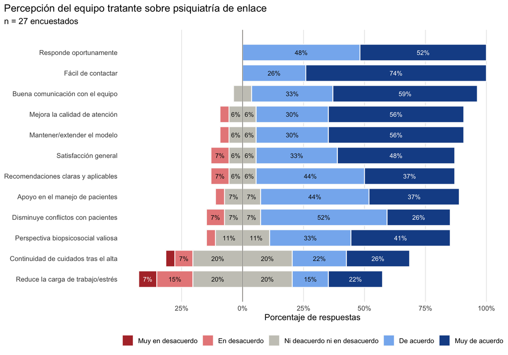

Los ítems con mayor acuerdo son la facilidad de contacto y la oportunidad de respuesta del equipo (100% de acuerdo o muy de acuerdo en ambos). Los de menor acuerdo son “reduce la carga de trabajo/estrés” y “continuidad de cuidados tras el alta”, con una proporción importante de respuestas neutras (41% en ambos casos).

## Diferencias por cargo

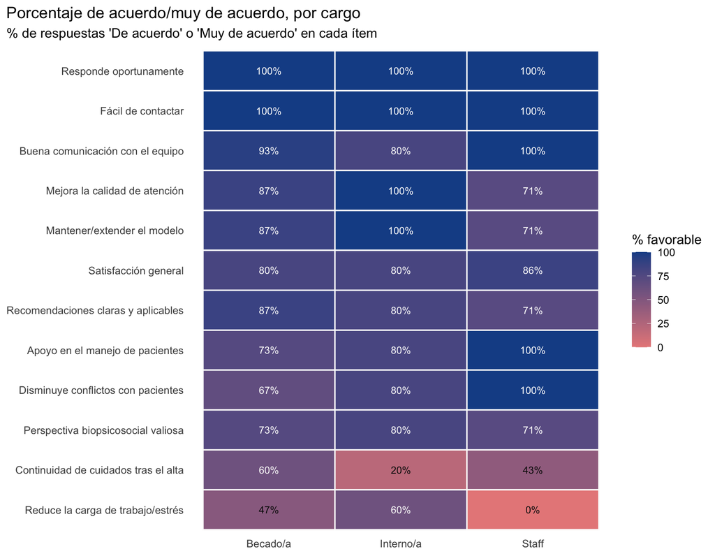

**Nota de lectura**: el grupo Interno/a tiene solo n = 5 respuestas, por lo que su porcentaje por celda es poco estable — se muestra de forma descriptiva, no debe interpretarse como una diferencia estadísticamente probada entre cargos.

## Índice de satisfacción vs. experiencia e interacciones

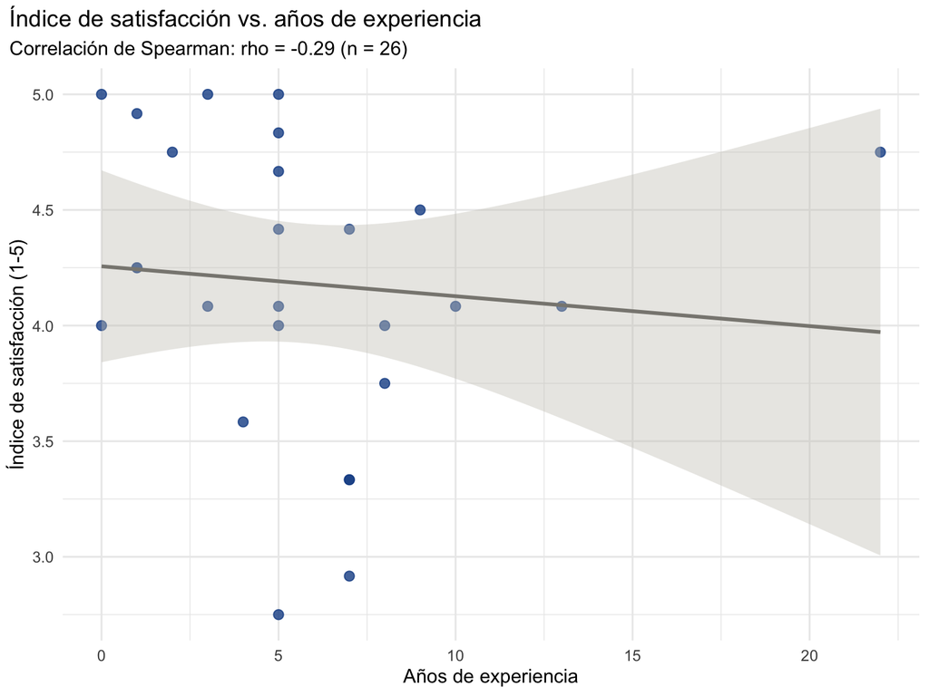

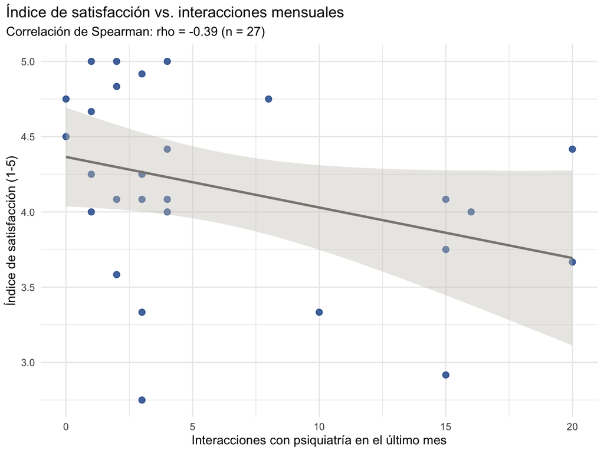

La correlación con años de experiencia es rho = -0.29 y con el número de interacciones mensuales es rho = -0.39; ambas deben leerse con cautela dado el n disponible.

## Consistencia interna de la escala (alpha de Cronbach)

| raw_alpha | std.alpha | G6(smc) | average_r | S/N | ase | mean | sd | median_r |
| --- | --- | --- | --- | --- | --- | --- | --- | --- |
| 0.92 | 0.91 | 0.96 | 0.47 | 10.74 | 0.02 | 4.16 | 0.62 | 0.51 |

Un alpha de 0.92 indica una consistencia interna muy alta entre los 12 ítems — es decir, se comportan como una sola escala coherente de satisfacción/percepción, y no como preguntas independientes.

| Ítem | Alpha si se elimina | Alpha std. si se elimina | Correlación ítem-resto |
| --- | --- | --- | --- |
| Responde oportunamente | 0.92 | 0.91 | 0.61 |
| Fácil de contactar | 0.93 | 0.93 | 0.10 |
| Recomendaciones claras y aplicables | 0.91 | 0.90 | 0.79 |
| Buena comunicación con el equipo | 0.92 | 0.91 | 0.48 |
| Continuidad de cuidados tras el alta | 0.91 | 0.90 | 0.71 |
| Mejora la calidad de atención | 0.91 | 0.90 | 0.76 |
| Apoyo en el manejo de pacientes | 0.91 | 0.90 | 0.74 |
| Perspectiva biopsicosocial valiosa | 0.91 | 0.91 | 0.69 |
| Reduce la carga de trabajo/estrés | 0.91 | 0.90 | 0.78 |
| Disminuye conflictos con pacientes | 0.91 | 0.91 | 0.67 |
| Satisfacción general | 0.91 | 0.90 | 0.85 |
| Mantener/extender el modelo | 0.91 | 0.90 | 0.79 |

**Nota metodológica**: el único ítem cuya eliminación *aumenta* el alpha (de 0.92 a 0.93) es “Fácil de contactar”, con una correlación ítem-resto casi nula (0.1) y correlaciones cercanas a cero o negativas con varios de los otros ítems (ver matriz de correlación más abajo). Esto sugiere que este ítem captura una dimensión distinta —la accesibilidad/logística de contacto con el equipo— más que la percepción de valor clínico o satisfacción general que domina el resto de la escala. Se optó por mantenerlo dentro del índice compuesto de 12 ítems, ya que el efecto sobre el alpha es marginal (un punto porcentual), pero se deja documentado como limitación a considerar si se quisiera reportar un subíndice de “accesibilidad” por separado en análisis futuros.

## Correlación entre ítems

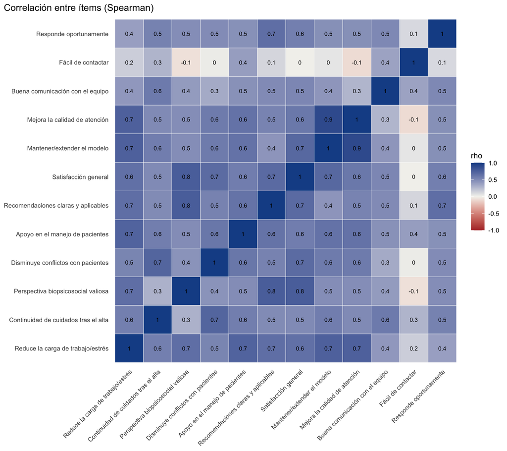

## Temas en las respuestas abiertas

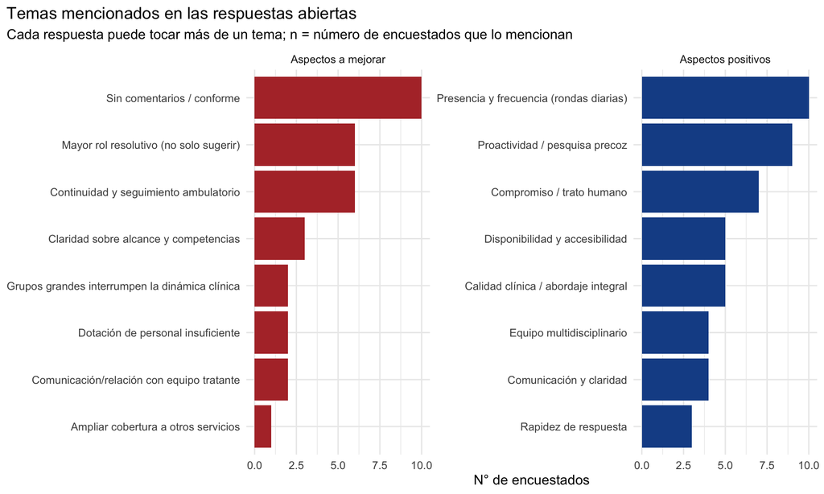

Entre los **aspectos positivos**, los temas más mencionados son la presencia y frecuencia del equipo (rondas diarias) y su proactividad en la pesquisa precoz de casos. Entre los **aspectos a mejorar**, después de quienes no identifican nada que mejorar, los temas más frecuentes son tener un rol más resolutivo (no solo sugerir manejo) y la continuidad del seguimiento ambulatorio tras el alta — el mismo patrón que ya aparecía en los ítems Likert peor evaluados.

## Limitaciones

- Muestra de conveniencia, pequeña (n = 27) y de un solo hospital: los resultados no son generalizables a otros centros.
- Las comparaciones por cargo tienen celdas chicas (Interno/a n = 5); se reportan como descriptivas, no como diferencias con significancia estadística probada.
- La codificación temática de las respuestas abiertas la realizó un solo codificador, sin una segunda persona que codificara en paralelo para medir acuerdo inter-codificador.
- El ítem “Fácil de contactar” correlaciona débilmente con el resto de la escala (ver sección de consistencia interna); se mantuvo en el índice compuesto porque el efecto sobre el alpha es marginal, pero probablemente mide accesibilidad más que satisfacción/valor clínico.

## Conclusiones

El modelo de psiquiatría de enlace es evaluado favorablemente por el equipo tratante, con una escala de percepción internamente consistente (alpha = 0.92). La oportunidad de respuesta y la facilidad de contacto son sus mayores fortalezas percibidas. La principal oportunidad de mejora, coincidente entre los ítems Likert y las respuestas abiertas, es fortalecer la continuidad de cuidados ambulatorios tras el alta y un rol más resolutivo del equipo (más allá de la sugerencia farmacológica).